# scRNAseq exercise

25-Nov-2025

Yuan Li (yuan.li@nbis.se)

First of all, we need to install some R packages:

```r
# In R:
install.packages("Seurat")
install.packages("ggplot2")
install.packages("Matrix", repos="http://R-Forge.R-project.org")
install.packages("patchwork")
install.packages("remotes")
remotes::install_github("chris-mcginnis-ucsf/DoubletFinder",
                        upgrade = FALSE, dependencies = TRUE)
if (!require("BiocManager", quietly = TRUE))
    install.packages("BiocManager")
BiocManager::install("scater", dependencies = TRUE)
install.packages("dplyr")
```

Import packages:

```r
suppressPackageStartupMessages({
    library(Seurat)
    library(Matrix)
    library(ggplot2)
    library(patchwork)
    library(DoubletFinder)
    library(scater)
})
```

# 1 Import data

The data we are analyzing now is from human peripheral blood mononuclear cells (PBMC) of healthy people, it’s only one single cell RNAseq dataset (acquired with the 10X Genomics technique), so no batch!

```r
data = readRDS("../data/normal_pbmc_5.RDS")
# Check the Seurat object
data
```

```
## An object of class Seurat
## 33538 features across 1500 samples within 1 assay
## Active assay: RNA (33538 features, 0 variable features)
##  1 layer present: counts
```

The dataset is now in the format of a Seurat object. The dataset has 1500 cells and 33538 genes. This object has only one assay so far: RNA. No highly variable genes have been selected yet. Within the RNA assay, there is only one data layer called `counts`, which is the raw count data, it hasn’t been normalized yet.

Check the raw count data:

```r
data[["RNA"]]$counts[1:5, 1:30]
```

```
## 5 x 30 sparse Matrix of class "dgCMatrix"
##
## MIR1302-2HG . . . . . . . . . . . . . . . . . . . . . . . . . . . . . .
## FAM138A     . . . . . . . . . . . . . . . . . . . . . . . . . . . . . .
## OR4F5       . . . . . . . . . . . . . . . . . . . . . . . . . . . . . .
## AL627309.1  . . . . . . . . . . . . . . . . . . . . . . . . . . . . . .
## AL627309.3  . . . . . . . . . . . . . . . . . . . . . . . . . . . . . .
```

The raw count data is now in a class dgCMatrix object.

dgCMatrix is a class of sparse numeric matrices.

In the sparse matrices, zeros are represented as “.”.

Sparse matrix saves memory when there are lots of zeros, which is typical for single cell data.

The rows of the counts matrix are genes, while the columns are cells (represented by cell barcodes)

# 2 Calculate quality control (QC) metrics for filtering

We can now start calculating some quality control metrics. We can for example calculate the percentage of mitochondrial protein genes per cell and add it to the metadata.

First let’s check the metadata we have so far

```r
data@meta.data[1:5, ]
```

|  | orig.ident | nCount_RNA | nFeature_RNA |
| --- | --- | --- | --- |
| AGGTCTAGTAGCTTAC-5 | ctrl_5 | 4291 | 1528 |
| TACTTACAGCCTCGTG-5 | ctrl_5 | 1545 | 594 |
| CCGGTGAGTAGTGGCA-5 | ctrl_5 | 1857 | 596 |
| TCAGGGCTCTCCCTAG-5 | ctrl_5 | 5780 | 1786 |
| CAAAGAAAGGAGGGTG-5 | ctrl_5 | 6278 | 2243 |

- row: cell
- nCount_RNA: total UMI count per cell
- nFeature_RNA: the number of genes that have been detected in a cell

```r
# Calcualte mitochondrial gene transcript percentage
data = PercentageFeatureSet(data, "^MT-", col.name = "percent_mito")

# Let's check the metadata again
data@meta.data[1:5, ]
# Can you see percent_mito now?
```

|  | orig.ident | nCount_RNA | nFeature_RNA | percent_mito |
| --- | --- | --- | --- | --- |
| AGGTCTAGTAGCTTAC-5 | ctrl_5 | 4291 | 1528 | 7.131205 |
| TACTTACAGCCTCGTG-5 | ctrl_5 | 1545 | 594 | 43.171521 |
| CCGGTGAGTAGTGGCA-5 | ctrl_5 | 1857 | 596 | 46.257404 |
| TCAGGGCTCTCCCTAG-5 | ctrl_5 | 5780 | 1786 | 6.608997 |
| CAAAGAAAGGAGGGTG-5 | ctrl_5 | 6278 | 2243 | 10.927047 |

Now we get the metadata columns: percent_mito in the metadata table

## 2.1 Plot QC metrics

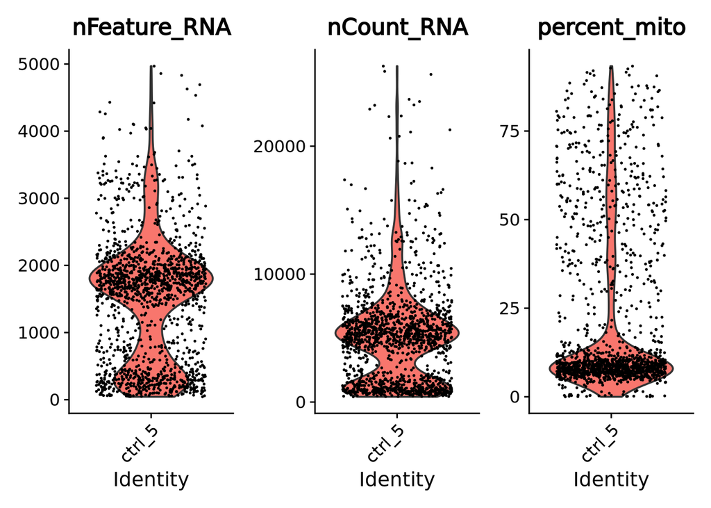

```r
feats = c("nFeature_RNA", "nCount_RNA", "percent_mito")
VlnPlot(data, features = feats, pt.size = 0.1, ncol = 3)
```

We can also make some scatter plots to understand the relationship between different metadata:

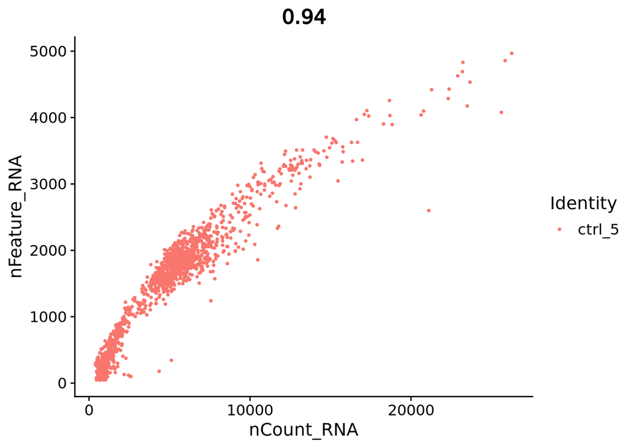

```r
FeatureScatter(data, "nCount_RNA", "nFeature_RNA", pt.size = .5)
# What's the relationship between nCount_RNA and nFeature_RNA? Are they positively correlated?
```

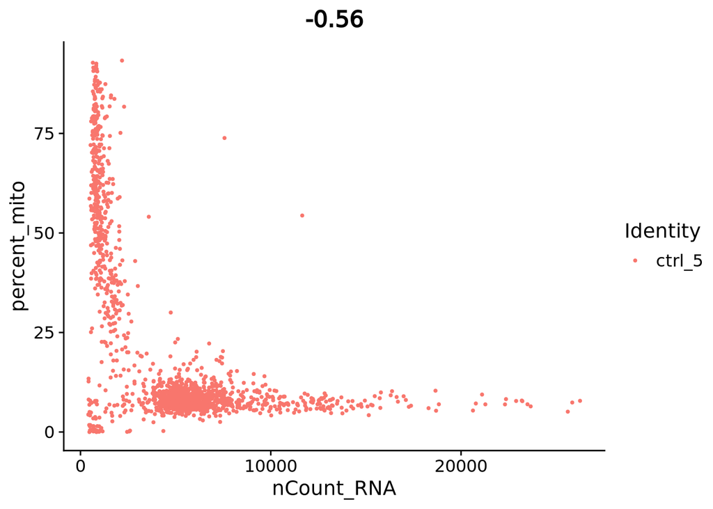

```r
FeatureScatter(data, "nCount_RNA", "percent_mito", pt.size = .5)
# Do those cells with high percent_mito tend to have low nCount_RNA? What does that mean?
```

# 3 Filtering

## 3.1 Detection-based filtering

### 3.1.1 Selet genes that are not lowly captured

So that we can remove lowly captured genes

```r
# We select genes expressed in more than 3 cells:
selected_f = rownames(data)[Matrix::rowSums(data[["RNA"]]$counts>0) > 3]
```

### 3.1.2 Select cells that capture more than 200 genes:

So that we can remove empty/dying cells.

```r
selected_c = WhichCells(data, expression = nFeature_RNA > 200)
```

### 3.1.3 Only keep the selected genes and cells:

```r
# Check how many cells and genes to start with
dim(data)

# Subset the seurat object to only keep the selected genes and cells:
data.filt = subset(data, features = selected_f, cells = selected_c)

# Check how many cells and genes left?
dim(data.filt)
```

```
## [1] 33538  1500
## [1] 13802  1371
```

## 3.2 Filter out broken, low quality cells further

This is mainly relevant for single cell RNAseq, may also be useful for single nucleus RNAseq!

From the FeatureScatter(data, “nCount_RNA”, “percent_mito”, pt.size = .5)-generated plot above, we can see that we have quite a lot of cells with high proportion of mitochondrial and low nCount_RNA. Those may be broken cells, it would be wise to remove them.

```r
# Select outlier cells with too high mitochondiral gene percentages
## We use a threshold of 3 MADs (Median Absolute Deviations) above the median as a cutoff
outlier_mt = isOutlier(data.filt@meta.data$percent_mito, nmads=3, type="higher", log=F)
data.filt@meta.data$outlier_mt = as.vector(outlier_mt)

# Select outlier cells with too low total cell UMI count
## We use a threshold of 3 MADs (Median Absolute Deviations) below the median as a cutoff
outlier_nCount_RNA = isOutlier(data.filt$nCount_RNA, nmads=3, type="lower", log=T)
data.filt@meta.data$outlier_nCount_RNA = as.vector(outlier_nCount_RNA)

# Combine the outlier information and add it to the metadata
data.filt@meta.data$Outlier_combined = data.filt@meta.data$outlier_mt | data.filt@meta.data$outlier_nCount_RNA

# Check the metadata table:
data.filt@meta.data[1:5, ]

# Now let's remove the identified outlier cells with either too high mitochondrial genes or too low total cell UMI count.
data.filt = subset(data.filt, Outlier_combined=="FALSE")

# Let's check how many cells do we have left now:
dim(data.filt)
```

|  | orig.ident | nCount_RNA | nFeature_RNA | percent_mito | outlier_mt | outlier_nCount_RNA | Outlier_combined |
| --- | --- | --- | --- | --- | --- | --- | --- |
| AGGTCTAGTAGCTTAC-5 | ctrl_5 | 4291 | 1528 | 7.131205 | FALSE | FALSE | FALSE |
| TACTTACAGCCTCGTG-5 | ctrl_5 | 1545 | 594 | 43.171521 | TRUE | FALSE | TRUE |
| CCGGTGAGTAGTGGCA-5 | ctrl_5 | 1857 | 596 | 46.257404 | TRUE | FALSE | TRUE |
| TCAGGGCTCTCCCTAG-5 | ctrl_5 | 5780 | 1786 | 6.608997 | FALSE | FALSE | FALSE |
| CAAAGAAAGGAGGGTG-5 | ctrl_5 | 6278 | 2243 | 10.927047 | FALSE | FALSE | FALSE |

```
## [1] 13802  1022
```

## 3.3 Plot the QC metrics again:

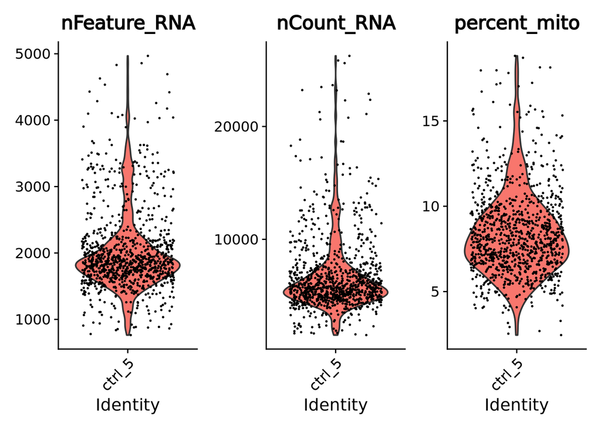

```r
feats = c("nFeature_RNA", "nCount_RNA", "percent_mito")
VlnPlot(data.filt, features = feats, pt.size = 0.1, ncol = 3)
```

And also check the relationship between QC metrics as well

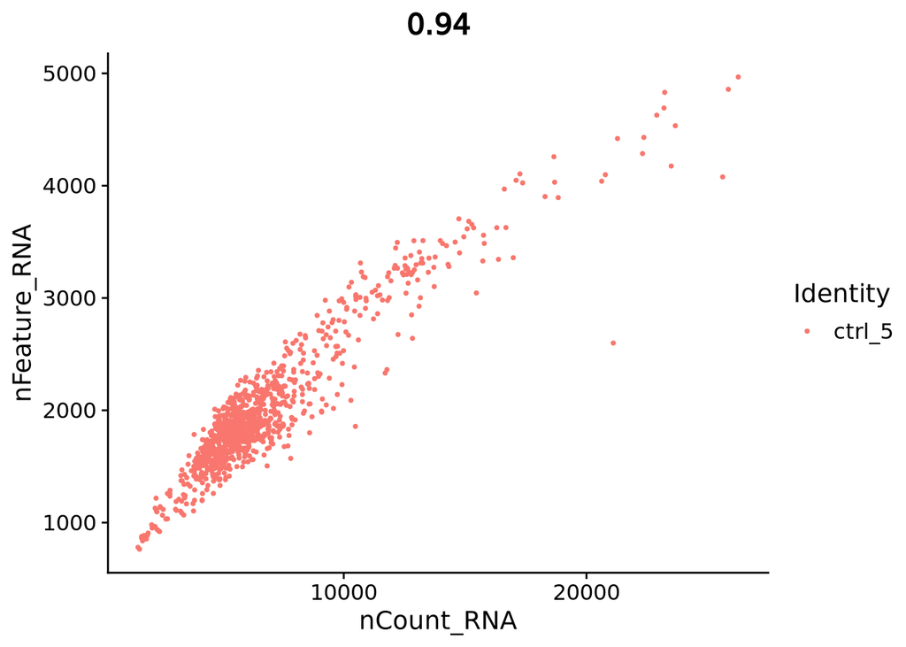

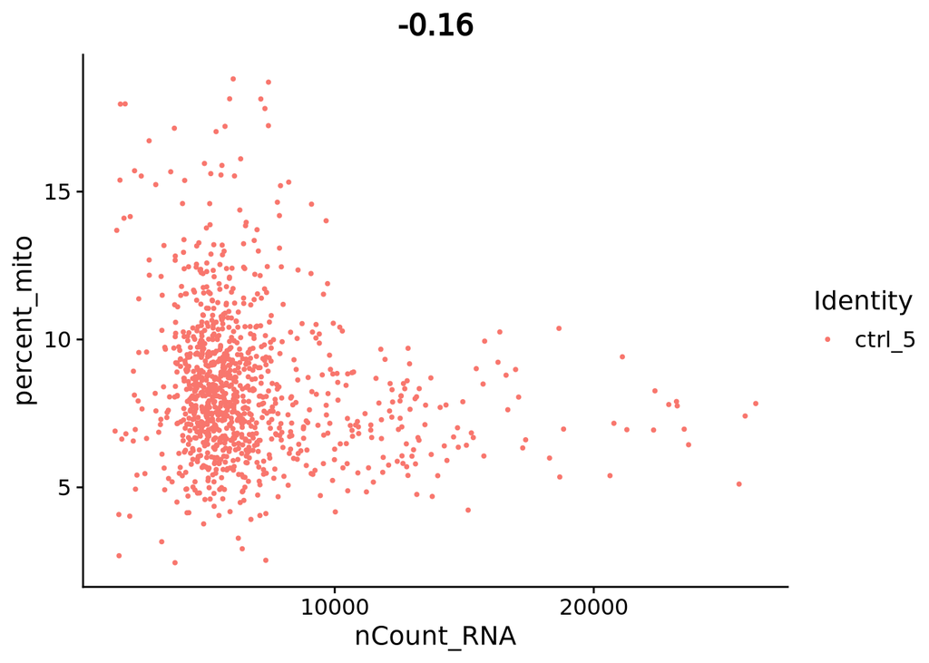

```r
FeatureScatter(data.filt, "nCount_RNA", "nFeature_RNA", pt.size = .5)
FeatureScatter(data.filt, "nCount_RNA", "percent_mito", pt.size = .5)
```

Compare the plots to those before filtering, do you think the filtering works?

# 4 Feel data

You can also make a histogram of the counts data

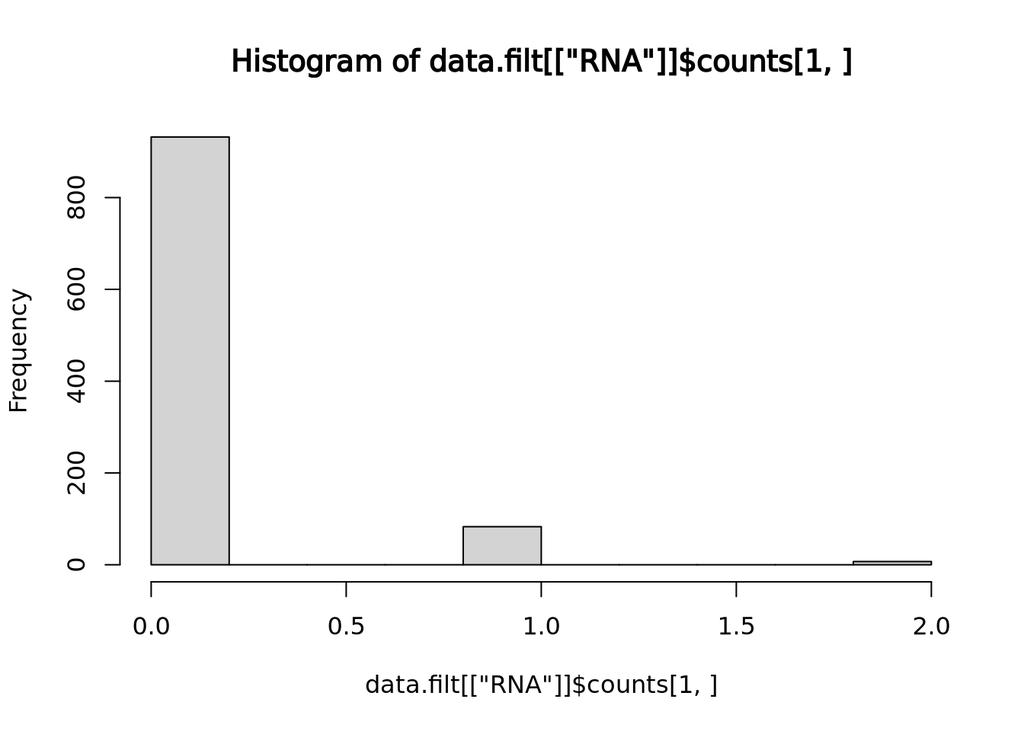

```r
# Check the 1st gene:
hist(data.filt[["RNA"]]$counts[1,], bin=30)
```

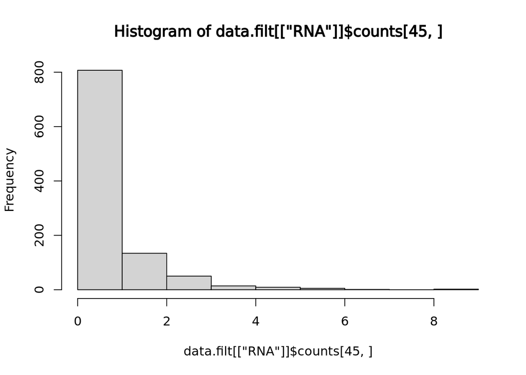

```r
# Check the 45th gene
hist(data.filt[["RNA"]]$counts[45,], bin=30)
```

How many zero counts do we have?

Check the zero rates of the Count data:

```r
counts = data.filt@assays$RNA$counts
(sum(counts==0)/(nrow(counts) * ncol(counts)))*100
```

```
## [1] 85.53104
```

# 5 Normalization using SCTransform()

Here, we will use SCTransform() to normalize the data:

```r
data.filt = SCTransform(data.filt, assay = "RNA",
                        new.assay.name = "SCT",
                        variable.features.n = 2000,
                        do.scale=T, do.center = T,
                        return.only.var.genes = T)
```

The SCTransform() function perform 3 tasks in on go:

- Normalizaiton
- Select highly variable genes
- Scaling

Let’s look at the SCT assay generated by SCTransform()

```r
data.filt
```

```
## An object of class Seurat
## 26818 features across 1022 samples within 2 assays
## Active assay: SCT (13016 features, 2000 variable features)
##  3 layers present: counts, data, scale.data
##  1 other assay present: RNA
```

You can see, we now got a new assay SCT, which is the currently active assay. It contains 3 layers: count, data, and scale.data.

- scale.data: Pearson residuals from the NB GLM model
- counts: corrected counts with sequencing depth effect removed, now the genes are supposed to be comparable among cells. This is the normalized count!
- data: log transformed corrected count

## 5.1 Scaled data

In the SCT assay, the scaled data are the pearson residuals from the NB GLM modeling

It is placed in the scale.data slot of the SCT assay

```r
data.filt[["SCT"]]
data.filt[["SCT"]]$scale.data[1:5, 1:5]
```

```
## SCTAssay data with 13016 features for 1022 cells, and 1 SCTModel(s)
## Top 10 variable features:
##  LYZ, IGKC, S100A9, S100A8, GNLY, IGHM, CST3, IGLC2, IGLC3, FCN1
##          AGGTCTAGTAGCTTAC-5 TCAGGGCTCTCCCTAG-5 CAAAGAAAGGAGGGTG-5
## HES4             -0.1324757         -0.1705927         -0.1795288
## ISG15            -0.4487764         -0.5084525         -0.5260320
## TNFRSF18         -0.2365623         -0.2679790         -0.2772606
## TNFRSF4          -0.1528450         -0.1942528         -0.2025505
## MIB2             -0.3503894         -0.3957007         -0.4090992
##          AATCGTGTCATTCGGA-5 GGTCACGCATTACGGT-5
## HES4             -0.2931908         -0.1568072
## ISG15             3.0039836         -0.4812564
## TNFRSF18          4.9506046         -0.2536447
## TNFRSF4          -0.3080593         -0.1814516
## MIB2             -0.5788959         -0.3750193
```

## 5.2 Highly variable genes

```r
# Let's first check how many highly variable genes have been selected:
data.filt
```

```
## An object of class Seurat
## 26818 features across 1022 samples within 2 assays
## Active assay: SCT (13016 features, 2000 variable features)
##  3 layers present: counts, data, scale.data
##  1 other assay present: RNA
```

Let’s also visualize highly variable genes/HVGs

HVGs are selected based on the the variance of the scaled data,

Pearson residuals are supposed to mainly reflect biological variation.

The calculation of residual variance is slightly more complicated than just applying the `var` function, for details, see the [get_residual_Var function](https://rdrr.io/github/satijalab/sctransform/src/R/utils.R)

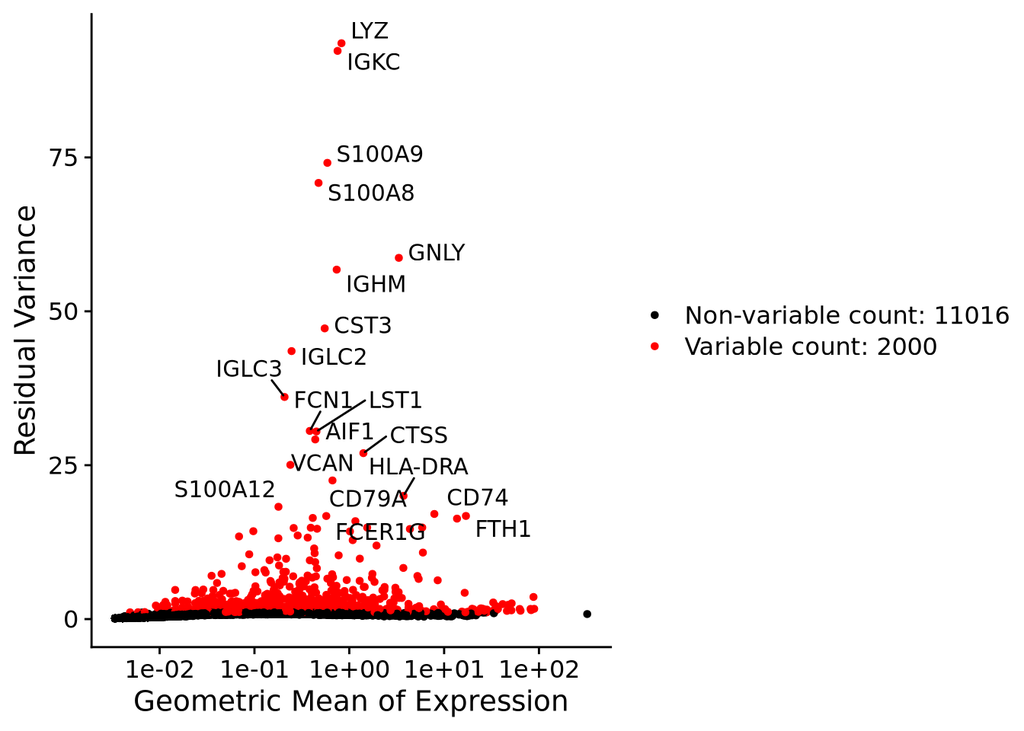

```r
top20 = head(VariableFeatures(data.filt), 20)
LabelPoints(plot = VariableFeaturePlot(data.filt,
    selection.method = "sct", assay = "SCT"),
    points = top20, repel = TRUE)
```

# 6 Cell cycle scoring

Here we will run cell cycle scoring to assign cells to different cell cycle phases (S phase, G2M phase).

We will get 2 scores:

- S.Score = average standardized expression of S genes
- G2M.Score = average standardized expression of G2M genes

```r
## Let's check what are the S genes
cc.genes$s.genes

## And also check what are the G2M genes
cc.genes$g2m.genes

## Let's do cell cycle scoring:
data.filt = CellCycleScoring(
    object = data.filt,
    g2m.features = cc.genes$g2m.genes,
    s.features = cc.genes$s.genes
)

# Check the metadata table, do you see the cell cycle phase scores now:
data.filt@meta.data[1:5, ]
```

```
##  [1] "MCM5"     "PCNA"     "TYMS"     "FEN1"     "MCM2"     "MCM4"
##  [7] "RRM1"     "UNG"      "GINS2"    "MCM6"     "CDCA7"    "DTL"
## [13] "PRIM1"    "UHRF1"    "MLF1IP"   "HELLS"    "RFC2"     "RPA2"
## [19] "NASP"     "RAD51AP1" "GMNN"     "WDR76"    "SLBP"     "CCNE2"
## [25] "UBR7"     "POLD3"    "MSH2"     "ATAD2"    "RAD51"    "RRM2"
## [31] "CDC45"    "CDC6"     "EXO1"     "TIPIN"    "DSCC1"    "BLM"
## [37] "CASP8AP2" "USP1"     "CLSPN"    "POLA1"    "CHAF1B"   "BRIP1"
## [43] "E2F8"
##  [1] "HMGB2"   "CDK1"    "NUSAP1"  "UBE2C"   "BIRC5"   "TPX2"    "TOP2A"
##  [8] "NDC80"   "CKS2"    "NUF2"    "CKS1B"   "MKI67"   "TMPO"    "CENPF"
## [15] "TACC3"   "FAM64A"  "SMC4"    "CCNB2"   "CKAP2L"  "CKAP2"   "AURKB"
## [22] "BUB1"    "KIF11"   "ANP32E"  "TUBB4B"  "GTSE1"   "KIF20B"  "HJURP"
## [29] "CDCA3"   "HN1"     "CDC20"   "TTK"     "CDC25C"  "KIF2C"   "RANGAP1"
## [36] "NCAPD2"  "DLGAP5"  "CDCA2"   "CDCA8"   "ECT2"    "KIF23"   "HMMR"
## [43] "AURKA"   "PSRC1"   "ANLN"    "LBR"     "CKAP5"   "CENPE"   "CTCF"
## [50] "NEK2"    "G2E3"    "GAS2L3"  "CBX5"    "CENPA"
```

|  | orig.ident | nCount_RNA | nFeature_RNA | percent_mito | outlier_mt | outlier_nCount_RNA | Outlier_combined | nCount_SCT | nFeature_SCT | S.Score | G2M.Score | Phase |
| --- | --- | --- | --- | --- | --- | --- | --- | --- | --- | --- | --- | --- |
| AGGTCTAGTAGCTTAC-5 | ctrl_5 | 4291 | 1528 | 7.131205 | FALSE | FALSE | FALSE | 5295 | 1518 | -0.01349907 | -0.03210310 | G1 |
| TCAGGGCTCTCCCTAG-5 | ctrl_5 | 5780 | 1786 | 6.608997 | FALSE | FALSE | FALSE | 5765 | 1772 | -0.01938977 | 0.04872255 | G2M |
| CAAAGAAAGGAGGGTG-5 | ctrl_5 | 6278 | 2243 | 10.927047 | FALSE | FALSE | FALSE | 6008 | 2226 | -0.06602928 | -0.05547587 | G1 |
| AATCGTGTCATTCGGA-5 | ctrl_5 | 15464 | 3045 | 9.014485 | FALSE | FALSE | FALSE | 6074 | 1777 | -0.00663433 | 0.01625122 | G2M |
| GGTCACGCATTACGGT-5 | ctrl_5 | 5066 | 1664 | 8.764311 | FALSE | FALSE | FALSE | 5455 | 1646 | -0.02703287 | -0.03780575 | G1 |

Let’s plot the cell cycle scores

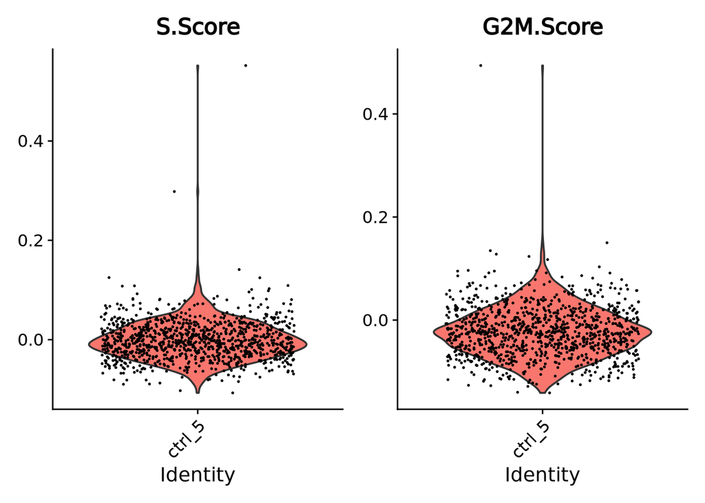

```r
VlnPlot(data.filt, features = c("S.Score", "G2M.Score"),
  group.by = "orig.ident", ncol = 2, pt.size = .1)
```

Seurat does an automatic prediction of cell cycle phases with a default cutoff of the scores at zero.

Let’s also look at the predict cell cycle phases:

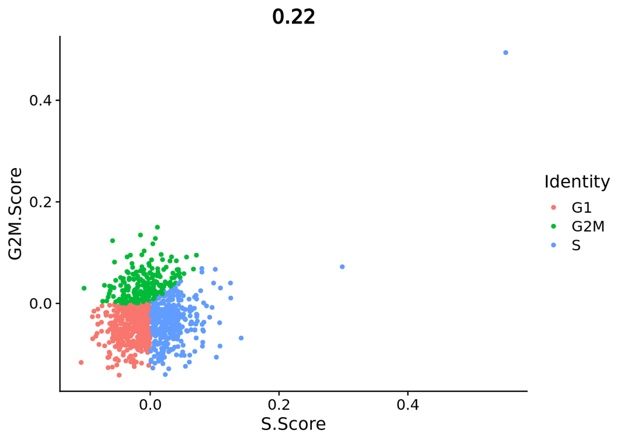

```r
FeatureScatter(data.filt, "S.Score", "G2M.Score", group.by = "Phase")
```

As you can see this does not fit this data very well (think about it, S.Score and G2M.Score close to 0), so be cautious with using these predictions. Instead we suggest that you look at the scores.

# 7 Remove doublets

We can also remove doublets, remember what doublets are? Why do we need to remove them Here, we will use `DoubletFinder` to predict doublet cells.

```r
source("../src/rmDoublets.R")
data.filt = rmDoublets(data.filt)
```

[output not shown]

[output cut: 229 more lines]

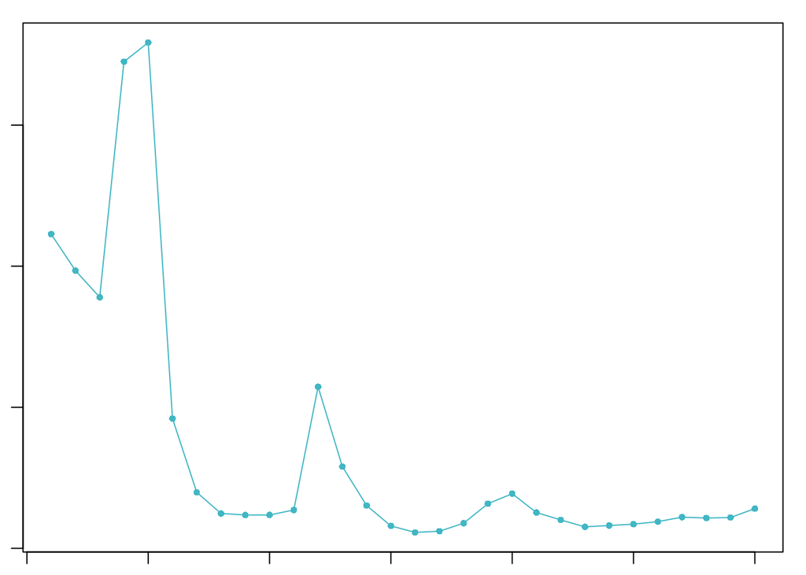

Now let’s check the metadata again, can you tell how many doublets have we found?

```r
head(data.filt@meta.data)
table(data.filt@meta.data$doublet_finder)
```

|  | orig.ident | nCount_RNA | nFeature_RNA | percent_mito | outlier_mt | outlier_nCount_RNA | Outlier_combined | nCount_SCT | nFeature_SCT | S.Score | G2M.Score | Phase | pANN_0.25_0.05_8 | doublet_finder |
| --- | --- | --- | --- | --- | --- | --- | --- | --- | --- | --- | --- | --- | --- | --- |
| AGGTCTAGTAGCTTAC-5 | ctrl_5 | 4289 | 1526 | 7.131205 | FALSE | FALSE | FALSE | 5295 | 1518 | -0.01349907 | -0.03210310 | G1 | 0.17647059 | Singlet |
| TCAGGGCTCTCCCTAG-5 | ctrl_5 | 5775 | 1781 | 6.608997 | FALSE | FALSE | FALSE | 5765 | 1772 | -0.01938977 | 0.04872255 | G2M | 0.26470588 | Singlet |
| CAAAGAAAGGAGGGTG-5 | ctrl_5 | 6270 | 2235 | 10.927047 | FALSE | FALSE | FALSE | 6008 | 2226 | -0.06602928 | -0.05547587 | G1 | 0.60294118 | Doublet |
| AATCGTGTCATTCGGA-5 | ctrl_5 | 15455 | 3036 | 9.014485 | FALSE | FALSE | FALSE | 6074 | 1777 | -0.00663433 | 0.01625122 | G2M | 0.10294118 | Singlet |
| GGTCACGCATTACGGT-5 | ctrl_5 | 5062 | 1660 | 8.764311 | FALSE | FALSE | FALSE | 5455 | 1646 | -0.02703287 | -0.03780575 | G1 | 0.01470588 | Singlet |
| TCGCTCAGTAAGTCAA-5 | ctrl_5 | 5145 | 1793 | 7.926948 | FALSE | FALSE | FALSE | 5488 | 1787 | 0.10777067 | -0.03810926 | S | 0.07352941 | Singlet |

```
##
## Doublet Singlet
##       8    1014
```

Let’s remvoe the doublet cells

```r
selected_c2 = WhichCells(data.filt, expression = doublet_finder=="Singlet")
data.filt = subset(data.filt, cells=selected_c2)
```

# 8 Save seurat object for later exploration

```r
saveRDS(data.filt, "../results/data.filt.RDS")
```

# 9 Recap

- Filtering
  - Filter cells: broken cells, low quality cells, doublets
  - Filter genes: lowly captured genes
- SCTransform:
  - Normalization
  - Select highly variable genes
  - Scaling
- Cell cycle scoring
- We could also remove cell-free RNA contamination using methods like cellbender, soupX …. but is not covered by this tutorial.

# 10 Save the package versions (important! Why?)